# IF240 - Machine Learning and Deep Learning

## TP 4 - Deep Neural Networks - Backpropagation - PyTorch

Compiled by Sneha Gupta, Shobhit Trehan and Charles Deledalle from PyTorch tutorials.  
Adapted by Aurélie Bugeau and Michaël Clément

```python
import numpy as np
import matplotlib.pyplot as plt
```

## 1. Neural network with NumPy

The objective is to learn the binary XOR function with a neural network. As seen in class, a neural network with only one layer cannot predict the XOR function. It has no hidden layer and no activation function, and can therefore only classify linearly separable sets. However the Universal Approximation Theorem states that a 2-layer neural network (with non-linear activation functions) can approximate any function.

The training set for the XOR function is defined as follows:

```python
# Each data point in the XOR dataset has two variables (or features), x1 and x2, that can be either 0 or 1
# The label to predict is their XOR combination (1 if x1 and x2 are different, 0 otherwise)
n_samples = 500
X_train = np.random.randint(low=0, high=2, size=(n_samples, 2)).astype('float32')
d_train = np.logical_xor(X_train[:, 0], X_train[:, 1]).astype('int')

# To make it slightly more challenging, we add a bit of gaussian noise to the data points.
std = 0.1
X_train += std * np.random.randn(n_samples, 2)
X_train = X_train.T
```

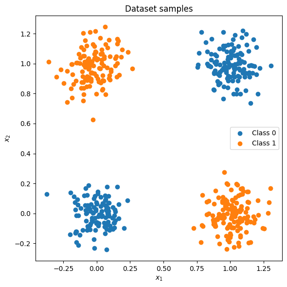

```python
def plot_dataset(X, y):
    plt.figure(figsize=(6, 6))
    plt.scatter(X[:, 0][y == 0], X[:, 1][y == 0], label="Class 0")
    plt.scatter(X[:, 0][y == 1], X[:, 1][y == 1], label="Class 1")
    plt.title("Dataset samples")
    plt.ylabel(r"$x_2$")
    plt.xlabel(r"$x_1$")
    plt.legend()
    plt.tight_layout()

plot_dataset(X_train.T, d_train)
```

```python
print(X_train.T.shape)
print(X_train.T)
print(d_train)
```

[output not shown]

[output cut: 460 more lines]

[output not shown]

### Defining the network

We will define a feedforward neural network with two layers: one hidden layer composed of two neurons, and one output layer with one neuron (for prediction).

The network has the following weights and biases to be trained: $(\mathbf{W}_1,~\mathbf{b}_1)$ for the hidden layer, and $(\mathbf{W}_2,~\mathbf{b}_2)$ for the output layer.

**(Question)** What are their dimensions? Initialize them randomly.

```python
#W is 2*2 dimensioned
#b is 2*1 dimensioned
import random
import math
b1 = np.random.rand(2,1)
print(b1)
W1 = np.random.rand(2,2)
print(W1)

W2 = np.random.rand(1,2)
b2 = random.random()
print(b2)
```

```
[[0.89369059]
 [0.95345043]]
[[0.31203157 0.13449792]
 [0.87036798 0.99784272]]
0.7293299166376477
```

### Activation functions

The feed-forward algorithm works as follows:

1. Each neuron $i$ in the hidden layer $l$ receives the weighted sum of the input values: $$a_i^l=\sum_j h_j^{l-1} w_{ij}^l + b^l_i$$
2. Each neuron calculates an output by using an activation function $g_1$ (typically sigmoid or ReLU): $$h_i^l= g_1(a_i^l)$$
3. Each neuron $i$ in the output layer $L$ receives the weighted sum of the last hidden layer: $$a_i^L =\sum_j h_j^{L-1} w_{ij}^{L} + b^L_i$$
4. The output layer neuron calculates an output by using possibly another activation function $g_2$ (depending on the application): $$y_i= g_2(a_i^L)$$

In case of classification, logistic activation functions such as sigmoid or softmax are usually used for the output layer.

**(Question)** Implement the linear, logistic sigmoid and ReLU functions, as well as their derivatives.

```python
def linear(a):
    return a

def d_linear(a):
    return np.ones(a.shape)

def sigmoid(a):
    return 1./(1.+np.exp(-a))

def d_sigmoid(a):
    return np.exp(-a)/((1+np.exp(-a))**2)

def relu(a):
    return np.maximum(0, a)

def d_relu(a):
    bool_sup = a<0
    return bool_sup.astype(int)
```

You will be able to experiment with the different functions by modifying the following cell:

```python
g1 = sigmoid
g2 = sigmoid
d_g1 = d_sigmoid
d_g2 = d_sigmoid

g2(d_train)
```

[output not shown]

[output cut: 45 more lines]

[output not shown]

### Loss function

To learn the parameters of the network we must compute the total loss of the forward pass ${\cal L}$.

It is computed by averaging the individual loss $L(y(\mathbf{x}), d)$ for each training sample $(\mathbf{x}, d)$ : $${\cal L} = \frac{1}{N} \sum_{(\mathbf{x},d)\in T} L(y(\mathbf{x}), d).$$ where $y(\mathbf{x})$ is the output of the network (prediction) and $d$ is the ground truth label.

Different loss functions $L$ can be used, depending on the problem. Here, because we are working on a binary classification problem, we will use the binary cross-entropy loss: $$L(y, d)= - (d\log (y)+ (1-d)\log(1-y))$$ and its derivative with respect to the outputs, which will be used for backpropagation: $$\frac{\partial L(y, d)}{\partial y} = -\frac{d}{y} + \frac{1 - d}{1 - y}$$

**(Question)** Complete the functions below to implement the total binary cross-entropy loss and its derivative with respect to the outputs.

```python
import math
def crossentropy(y, d):
    # Return a scalar corresponding to the total loss.
    # It should be the average of the binary cross-entropy
    # for each element in `y` (predictions) and `d` (ground truth labels)
    return np.sum(-(d*np.log(y)+(1-d)*np.log(1-y)))/y.shape[0]


def d_crossentropy(y, d):
    # Return a vector of partial derivatives of the binary cross-entropy loss
    # with respect to each of the predictions.
    return -d/y + (1-d)/(1-y)

print(d_train.shape)
a = np.random.rand(d_train.shape[0], 1)

print(d_crossentropy(a, d_train))
```

```
(500,)
[[ 2.64287738 -1.60868816  2.64287738 ... -1.60868816 -1.60868816
   2.64287738]
 [ 2.04781059 -1.95437096  2.04781059 ... -1.95437096 -1.95437096
   2.04781059]
 [ 1.26448805 -4.78088909  1.26448805 ... -4.78088909 -4.78088909
   1.26448805]
 ...
 [ 2.15939836 -1.86251631  2.15939836 ... -1.86251631 -1.86251631
   2.15939836]
 [ 1.83065473 -2.20386962  1.83065473 ... -2.20386962 -2.20386962
   1.83065473]
 [ 2.59275961 -1.62784113  2.59275961 ... -1.62784113 -1.62784113
   2.59275961]]
```

### Training the neural network

**(Question)** Complete the code below to implement a training iteration of the neural network.

```python
lr = 0.01 # learning rate
n_epochs = 1000

for k in range(n_epochs):

    # Compute a1, h1, a2 and y
    a1 = np.dot(W1,X_train)+b1
    h1 = g1(a1)
    a2 = np.dot(W2, h1) + b2
    #print(a2)
    y = g2(a2)
    #print(y)

    # Compute the loss
    loss = crossentropy(y, d_train)
    #print(loss.shape)

    if (k + 1) % 100 == 0:
        print("[epoch {:04d}] loss = {:.4f}".format(k + 1, loss))

    # Backpropagation
    # Compute delta2 and then delta1
    delta2 = (d_g2(a2))*(d_crossentropy(y,d_train))
    delta1 = (d_g1(a1))*((W2.T).dot(delta2))

    # Compute the derivative of the loss with respect to the parameters
    dW2 = delta2.dot(h1.T)
    db2 = delta2.sum(axis=1, keepdims=True)
    dW1 = delta1.dot(X_train.T)
    db1 = delta1.sum(axis=1, keepdims=True)

    # Weights update
    # Apply gradient descent to update the parameters
    #print('dW2', dW2.shape)
    #print(W1.shape)
    #print(dW1.shape)
    W2 = np.subtract(W2, lr*dW2) #bon
    #print(dW2)
    #print(W2)
    W1 = np.subtract(W1, dW1*lr)

    b1 = np.subtract(b1, lr*db1)
    b2 = np.subtract(b2, lr*db2)
```

```
[epoch 0100] loss = 345.3357
[epoch 0200] loss = 229.4584
[epoch 0300] loss = 14.8010
[epoch 0400] loss = 6.8803
[epoch 0500] loss = 4.4901
[epoch 0600] loss = 3.3372
[epoch 0700] loss = 2.6583
[epoch 0800] loss = 2.2107
[epoch 0900] loss = 1.8932
[epoch 1000] loss = 1.6563
```

### Testing and decision boundary

To test the network, we will evaluate the results on each point of a square [0,1]$\times$[0,1] grid (like in the previous TP).

**(Question)** Complete the code below to apply the forward pass on the test data.

```
[[0.         0.01010101 0.02020202 ... 0.97979798 0.98989899 1.        ]
 [0.         0.01010101 0.02020202 ... 0.97979798 0.98989899 1.        ]
 [0.         0.01010101 0.02020202 ... 0.97979798 0.98989899 1.        ]
 ...
 [0.         0.01010101 0.02020202 ... 0.97979798 0.98989899 1.        ]
 [0.         0.01010101 0.02020202 ... 0.97979798 0.98989899 1.        ]
 [0.         0.01010101 0.02020202 ... 0.97979798 0.98989899 1.        ]]
```

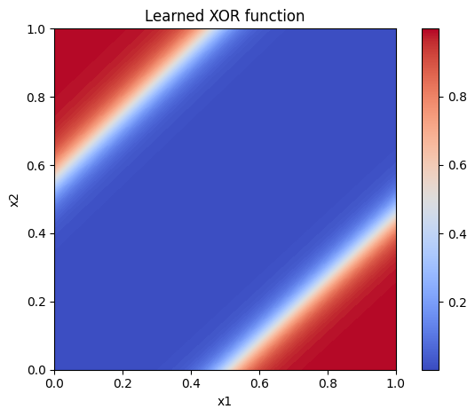

```python
def predict(x):
    a1 = np.dot(W1,x)+b1
    h1 = g1(a1)
    a2 = np.dot(W2, h1) + b2
    y = g2(a2)
    return y


xx1, xx2 = np.meshgrid(np.linspace(0, 1, num=100),
                       np.linspace(0, 1, num=100))
X_test = np.stack((xx1.reshape(-1), xx2.reshape(-1)))

y_pred=predict(X_test)

print(xx1)

Z = y_pred.reshape(xx1.shape)

plt.contourf(xx1, xx2, Z, levels=100, cmap='coolwarm')

plt.imshow(y_pred, extent=[0, 1, 0, 1], origin='lower', cmap='coolwarm')
plt.xlabel('x1')
plt.ylabel('x2')
plt.title('Learned XOR function')
plt.colorbar()
plt.tight_layout()
```

**(Question)** Explain the result.

Les points appartenant à la même classe sont situés au niveau des coins opposés du graphique. Donc une diagonale bleue apparait avec des coins opposés en rouge.

## 2. Introduction to PyTorch

PyTorch is a Python based scientific computing package targeted at two sets of audiences:

- a replacement for NumPy to use the power of GPUs,
- a deep learning research platform that provides maximum flexibility and speed.

For more documentation, please visit: http://pytorch.org/tutorials/beginner/deep_learning_60min_blitz.html

```python
import torch
```

### Tensors

Torch tensors are similar to NumPy ndarrays, with the addition being that they can also be used on a GPU to accelerate computing.

The documentation for tensors is available here: http://pytorch.org/docs/stable/tensors.html

```python
# Construct a 5x3 tensor and print it
x = torch.Tensor(5, 3)
print(x)
print(x.shape, x.dtype)
```

```
tensor([[-3.6098e+03,  4.5705e-41, -3.6098e+03],
        [ 4.5705e-41,  0.0000e+00,  0.0000e+00],
        [ 0.0000e+00,  0.0000e+00,  9.5906e+14],
        [ 4.5705e-41,  2.1217e-10, -1.8334e-22],
        [ 6.9610e-12,  4.5705e-41,  7.1522e-12]])
torch.Size([5, 3]) torch.float32
```

```python
# Construct a randomly initialized matrix
# where each entry is a random number pulled from a uniform distribution from 0 to 1
y = torch.rand(5, 3)
print(y)
print(y.shape, y.dtype)
```

```
tensor([[0.2270, 0.2716, 0.2773],
        [0.3292, 0.2825, 0.4957],
        [0.1227, 0.4629, 0.7704],
        [0.3772, 0.4668, 0.3692],
        [0.1900, 0.9014, 0.5299]])
torch.Size([5, 3]) torch.float32
```

```python
# Conversions
y = y.double()
print(y, y.dtype)
```

```
tensor([[0.2270, 0.2716, 0.2773],
        [0.3292, 0.2825, 0.4957],
        [0.1227, 0.4629, 0.7704],
        [0.3772, 0.4668, 0.3692],
        [0.1900, 0.9014, 0.5299]], dtype=torch.float64) torch.float64
```

```python
# You can also initialize tensors directly with predefined values
x = torch.Tensor([[-0.1859, 1.3970, 0.5236],
                  [ 2.3854, 0.0707, 2.1970],
                  [-0.3587, 1.2359, 1.8951],
                  [-0.1189, -0.1376, 0.4647],
                  [-1.8968, 2.0164, 0.1092]])
y = torch.Tensor([[ 0.4838, 0.5822, 0.2755],
                  [ 1.0982, 0.4932, -0.6680],
                  [ 0.7915, 0.6580, -0.5819],
                  [ 0.3825, -1.1822, 1.5217],
                  [ 0.6042, -0.2280, 1.3210]])
print(x.shape, y.shape)
```

```
torch.Size([5, 3]) torch.Size([5, 3])
```

```python
# You can stack the two 2d tensors in a 3d tensor as
z = torch.stack((x, y))
print(z)
print(z.shape)
```

```
tensor([[[-0.1859,  1.3970,  0.5236],
         [ 2.3854,  0.0707,  2.1970],
         [-0.3587,  1.2359,  1.8951],
         [-0.1189, -0.1376,  0.4647],
         [-1.8968,  2.0164,  0.1092]],

        [[ 0.4838,  0.5822,  0.2755],
         [ 1.0982,  0.4932, -0.6680],
         [ 0.7915,  0.6580, -0.5819],
         [ 0.3825, -1.1822,  1.5217],
         [ 0.6042, -0.2280,  1.3210]]])
torch.Size([2, 5, 3])
```

```python
# Concatenates in the given dimension
z2 = torch.cat((x, y), dim=0)
print(z2)
print(z2.shape)
```

```
tensor([[-0.1859,  1.3970,  0.5236],
        [ 2.3854,  0.0707,  2.1970],
        [-0.3587,  1.2359,  1.8951],
        [-0.1189, -0.1376,  0.4647],
        [-1.8968,  2.0164,  0.1092],
        [ 0.4838,  0.5822,  0.2755],
        [ 1.0982,  0.4932, -0.6680],
        [ 0.7915,  0.6580, -0.5819],
        [ 0.3825, -1.1822,  1.5217],
        [ 0.6042, -0.2280,  1.3210]])
torch.Size([10, 3])
```

```python
# You can use standard NumPy-like indexing
print(x[:, 1])
```

```
tensor([ 1.3970,  0.0707,  1.2359, -0.1376,  2.0164])
```

```python
# Adding two tensors i
print('x+y = ', x + y)
print('torch.add(x, y) = ', torch.add(x, y))
print('x.add(y) = ', x.add(y))
torch.add(x, y, out=x)
print('torch.add(x, y, out=x) = ', x)
```

```
x+y =  tensor([[ 0.2979,  1.9792,  0.7991],
        [ 3.4836,  0.5639,  1.5290],
        [ 0.4328,  1.8939,  1.3132],
        [ 0.2636, -1.3198,  1.9864],
        [-1.2926,  1.7884,  1.4302]])
torch.add(x, y) =  tensor([[ 0.2979,  1.9792,  0.7991],
        [ 3.4836,  0.5639,  1.5290],
        [ 0.4328,  1.8939,  1.3132],
        [ 0.2636, -1.3198,  1.9864],
        [-1.2926,  1.7884,  1.4302]])
x.add(y) =  tensor([[ 0.2979,  1.9792,  0.7991],
        [ 3.4836,  0.5639,  1.5290],
        [ 0.4328,  1.8939,  1.3132],
        [ 0.2636, -1.3198,  1.9864],
        [-1.2926,  1.7884,  1.4302]])
torch.add(x, y, out=x) =  tensor([[ 0.2979,  1.9792,  0.7991],
        [ 3.4836,  0.5639,  1.5290],
        [ 0.4328,  1.8939,  1.3132],
        [ 0.2636, -1.3198,  1.9864],
        [-1.2926,  1.7884,  1.4302]])
```

```python
# Reshape a tensor with torch.view
x = torch.randn(4, 4)
y = x.view(16)
z = x.view(-1, 8) # the size -1 is inferred from other dimensions
print(x.size(), y.size(), z.size())
```

```
torch.Size([4, 4]) torch.Size([16]) torch.Size([2, 8])
```

```python
# Any operation that mutates a tensor in-place is post-fixed with an _. For example:
x = torch.Tensor([[1, 2],
                  [3, 4]])
y = torch.Tensor([[-1, -2],
                  [-3, -4]])

print('x before=', x)
x.copy_(y)
print('x after copying y =', x)
x.t_() # will change x
print('x after transpose =', x)
print('y has not changed=', y)
```

```
x before= tensor([[1., 2.],
        [3., 4.]])
x after copying y = tensor([[-1., -2.],
        [-3., -4.]])
x after transpose = tensor([[-1., -3.],
        [-2., -4.]])
y has not changed= tensor([[-1., -2.],
        [-3., -4.]])
```

### Matrix multiplication

**(Question)** Generate two random tensors $x$ and $y$ of dimensions 10$\times$10 and 2$\times$100, respectively, resize them such that the instruction `torch.mm(x, y)` performs a row-vector by matrix multiplication resulting in a row-vector $z$ of dimension 1$\times$ 2.

```python
x = torch.rand(10, 10)
y = torch.rand(2, 100)


print(x)
print(x.shape, x.dtype)
print(y)
print(y.shape, y.dtype)

x = x.view(1,100)
y = y.view(100,2)

z = torch.mm(x, y)
print(z)
print(z.shape, z.dtype)
```

```
tensor([[0.9260, 0.7407, 0.2296, 0.0797, 0.8705, 0.8382, 0.1511, 0.0660, 0.2171,
         0.9884],
        [0.7382, 0.2620, 0.4003, 0.0644, 0.3725, 0.3073, 0.0852, 0.1842, 0.6622,
         0.1881],
        [0.2145, 0.5905, 0.6012, 0.4635, 0.6351, 0.9603, 0.4388, 0.2254, 0.6987,
         0.5130],
        [0.5176, 0.9273, 0.3380, 0.2660, 0.8130, 0.5564, 0.5587, 0.8240, 0.3896,
         0.0686],
        [0.6417, 0.0279, 0.4703, 0.6143, 0.0010, 0.9935, 0.5996, 0.6235, 0.1128,
         0.8094],
        [0.2098, 0.0330, 0.1519, 0.2656, 0.3896, 0.8149, 0.2607, 0.5958, 0.2618,
         0.3712],
        [0.0725, 0.6906, 0.3027, 0.1142, 0.4401, 0.7523, 0.9899, 0.7522, 0.3662,
         0.0139],
        [0.9811, 0.8892, 0.1970, 0.2548, 0.5501, 0.2982, 0.2104, 0.3167, 0.0878,
         0.8460],
        [0.1234, 0.7668, 0.6860, 0.6119, 0.0388, 0.6417, 0.3367, 0.6974, 0.6703,
         0.0567],
        [0.3469, 0.4415, 0.5073, 0.9547, 0.3310, 0.6950, 0.9883, 0.9096, 0.7955,
         0.1886]])
torch.Size([10, 10]) torch.float32
tensor([[0.0499, 0.1177, 0.7855, 0.3784, 0.6323, 0.0474, 0.0274, 0.0345, 0.7949,
         0.5330, 0.6312, 0.5069, 0.0138, 0.0617, 0.7959, 0.2715, 0.4331, 0.3624,
         0.9745, 0.4211, 0.0606, 0.7599, 0.4925, 0.6296, 0.0808, 0.3234, 0.9776,
         0.5455, 0.0885, 0.3586, 0.6290, 0.7790, 0.8878, 0.0642, 0.0318, 0.5185,
         0.0979, 0.1553, 0.2143, 0.9466, 0.2863, 0.3286, 0.8170, 0.4916, 0.0395,
         0.9177, 0.0665, 0.8958, 0.6616, 0.0097, 0.7335, 0.2542, 0.5735, 0.0777,
         0.5346, 0.3936, 0.8144, 0.3337, 0.3493, 0.4435, 0.6731, 0.6395, 0.9113,
         0.6111, 0.9394, 0.8098, 0.7293, 0.8741, 0.8999, 0.2579, 0.9845, 0.0516,
         0.2704, 0.3294, 0.9339, 0.7217, 0.7829, 0.9682, 0.6009, 0.1261, 0.2205,
         0.9433, 0.0843, 0.0387, 0.8422, 0.7311, 0.8587, 0.8446, 0.6947, 0.3956,
         0.8423, 0.5482, 0.7237, 0.1471, 0.2373, 0.6985, 0.8391, 0.3065, 0.1699,
         0.5424],
        [0.3259, 0.8655, 0.2331, 0.0250, 0.7138, 0.4953, 0.9800, 0.5626, 0.6154,
         0.3092, 0.5332, 0.6187, 0.4107, 0.9867, 0.1758, 0.5023, 0.4421, 0.4011,
         0.3652, 0.6584, 0.9283, 0.6177, 0.9403, 0.0262, 0.6262, 0.9712, 0.8785,
         0.9741, 0.2483, 0.6554, 0.3530, 0.3400, 0.7055, 0.9225, 0.7724, 0.2595,
         0.7203, 0.5468, 0.9852, 0.3913, 0.3533, 0.4493, 0.3070, 0.5228, 0.2313,
         0.3927, 0.3569, 0.8385, 0.5135, 0.6353, 0.1741, 0.7379, 0.9955, 0.0831,
         0.2853, 0.4348, 0.4994, 0.3186, 0.6307, 0.2106, 0.3527, 0.1844, 0.7642,
         0.3622, 0.2112, 0.0717, 0.3278, 0.2795, 0.1447, 0.4981, 0.9825, 0.6376,
         0.8915, 0.3164, 0.4374, 0.3613, 0.5698, 0.7507, 0.9591, 0.2436, 0.2327,
         0.9791, 0.9152, 0.2935, 0.4013, 0.6948, 0.9891, 0.8208, 0.6344, 0.2638,
         0.9054, 0.2173, 0.7111, 0.9942, 0.3156, 0.1539, 0.8726, 0.7087, 0.2586,
         0.6846]])
torch.Size([2, 100]) torch.float32
tensor([[26.9494, 23.3142]])
torch.Size([1, 2]) torch.float32
```

### NumPy arrays and PyTorch tensors

Torch tensors and NumPy arrays can be converted to each other. They usually share the same underlying memory location:

```python
# From Torch to NumPy
a = torch.ones(5)
b = a.numpy()
print('a = ', a)
print('b = ', b)
print(a.type(), type(b))
a += 1
print('a = ', a)
print('b = ', b)
```

```
a =  tensor([1., 1., 1., 1., 1.])
b =  [1. 1. 1. 1. 1.]
torch.FloatTensor <class 'numpy.ndarray'>
a =  tensor([2., 2., 2., 2., 2.])
b =  [2. 2. 2. 2. 2.]
```

```python
# From NumPy to Torch
a = np.ones(5)
b = torch.from_numpy(a)
print('a = ', a)
print('b = ', b)
a += 1
print('a = ', a)
print('b = ', b)
```

```
a =  [1. 1. 1. 1. 1.]
b =  tensor([1., 1., 1., 1., 1.], dtype=torch.float64)
a =  [2. 2. 2. 2. 2.]
b =  tensor([2., 2., 2., 2., 2.], dtype=torch.float64)
```

### Running on GPU

Torch tensors can be moved onto GPU device's memory using `.to('cuda')` or `.cuda()` and back to CPU device with `.to('cpu')` or `.cpu()`.

Alternatively, a tensor can be directly allocated into the GPU using the device optional argument.

```python
# Use cuda if a GPU is available, otherwise stay on CPU
device = 'cuda' if torch.cuda.is_available() else 'cpu'
print(device)

x = torch.randn(5, 3).to(device)
y = torch.randn(5, 3, device=device)
z = x + y

print(z.cpu().numpy())
```

```
cpu
[[ 6.1206713e-02  1.1608592e+00  4.6309736e-01]
 [-1.8340379e+00  1.4875725e-01 -2.4491024e-01]
 [-1.6988647e+00  1.1690329e-01  1.2698066e-01]
 [ 5.8274776e-01  2.1754379e+00  1.3321435e+00]
 [-2.5200844e-03  2.6621962e+00 -2.4603610e-01]]
```

Note that moving data from CPU to GPU is slow, so try to do all the computations in GPU, and transfer the data back to CPU once all computations have been performed.

Note also that newer versions of PyTorch come with more advanced tools for manipulating GPU/CPU devices.

## 3. Automatic differentiation - Backpropagation

A central feature in PyTorch is the `autograd` package. It provides tools performing automatic differentiation for all operations based on Torch tensors. This means that the gradients of such operations will not require to be explicitly programmed. It uses a *define-by-run framework* that computes these gradients dynamically during runtime. This is really useful to apply the backpropagation algorithm, since `autograd` will deduce automatically from the succession of forward operations what are the corresponding backward updates.

A Torch tensor stores a flag `requires_grad`. By default, this attribute is set to *False*. If you set it to *True*, autograd will track all operations where this Tensor is involved. Any other tensor resulting from operations involving this tensor will have its `requires_grad` attribute set to *True* automatically. When you finish your computation you can call `.backward()` and have the gradients computed automatically for all these tensors. The gradient for these tensors will be accumulated into the `.grad` attribute.

**(Question)** Analyze the equation $f(x_1,x_2,x_3,x_4)=x_1+x_2+x_3+x_4$ implemented below. Derive the partial derivatives for each $x_i$. Compare your result with the *autograd* result.

```python
def f(x):
    return x.sum()

def d_f(x):
    y = torch.Tensor(1, len(x))
    for xi in range(len(x)):
        y[0][xi] = x[xi].item()/x[xi].item()
    return y

x = torch.rand(4, requires_grad=True)
print(x[1].item())
y = f(x)
print('x =', x)
print('y =', y)

manual_grad = d_f(x)
print('manual grad =', manual_grad)

y.backward()
auto_grad = x.grad
print('auto grad =', auto_grad)
```

```
0.7466400265693665
x = tensor([0.4316, 0.7466, 0.8947, 0.5162], requires_grad=True)
y = tensor(2.5891, grad_fn=<SumBackward0>)
manual grad = tensor([[1., 1., 1., 1.]])
auto grad = tensor([1., 1., 1., 1.])
```

**(Question)** Same question for the following equation: $f(x) = f(x_1,x_2,x_3,x_4)=\frac{1}{4}\sum_i 3(x_i+2)^2$

```python
def f(x):
    return (1 / 4) * torch.sum(3 * (x + 2) ** 2)

def d_f(x):
    y = torch.Tensor(1, len(x))
    for xi in range(len(x)):
        y[0][xi] =  (1 / 4) * 3 * 2 *(x[xi].item()+2)
    return y

x = torch.rand(4, requires_grad=True)
y = f(x)
print('x =', x)
print('y =', y)

manual_grad = d_f(x)
print('manual grad =', manual_grad)

y.backward()
auto_grad = x.grad
print('auto grad =', auto_grad)
```

```
x = tensor([0.8765, 0.6613, 0.0210, 0.6264], requires_grad=True)
y = tensor(19.7545, grad_fn=<MulBackward0>)
manual grad = tensor([[4.3148, 3.9919, 3.0314, 3.9397]])
auto grad = tensor([4.3148, 3.9919, 3.0314, 3.9397])
```

## 4. Implementing a neural network in PyTorch

Let us rewrite the XOR neural network with PyTorch, following the tutorial at: https://uvadlc-notebooks.readthedocs.io/en/latest/tutorial_notebooks/tutorial2/Introduction_to_PyTorch.html

### Dataset and batches

PyTorch provides some functionalities to load the training and test data efficiently. The data package defines two classes which are the standard interface for handling data in PyTorch:

```python
from torch.utils.data import Dataset, DataLoader
```

The dataset class summarizes the basic functionality of a dataset. To define a dataset in PyTorch, we specify two functions: `__getitem__`, and `__len__`.

For the XOR dataset, we can define the dataset class as follows:

```python
class XOR_Dataset(Dataset):

    def __init__(self, n_samples, std=0.1):
        """
        Inputs:
            n_samples - Number of data points we want to generate
            std - Standard deviation of the noise
        """
        super().__init__()
        self.n_samples = n_samples
        self.std = std
        # Generate data samples
        self.data = torch.randint(low=0, high=2, size=(self.n_samples, 2), dtype=torch.float32)
        self.labels = (self.data.sum(dim=1) == 1).to(torch.int)
        self.data += self.std * torch.randn(self.data.shape)

    def __len__(self):
        # Number of data points we have. Alternatively self.data.shape[0], or self.labels.shape[0]
        return self.n_samples

    def __getitem__(self, index):
        # Return the index-th data point of the dataset
        # If we have multiple things to return (data point and label), we can return them as tuple
        data_point = self.data[index]
        data_label = self.labels[index]
        return data_point, data_label
```

```python
train_dataset = XOR_Dataset(n_samples=500)
```

**(Question)** What is the size of the dataset? Plot the data points as in the beginning of the TP.

```
torch.Size([500, 2])
```

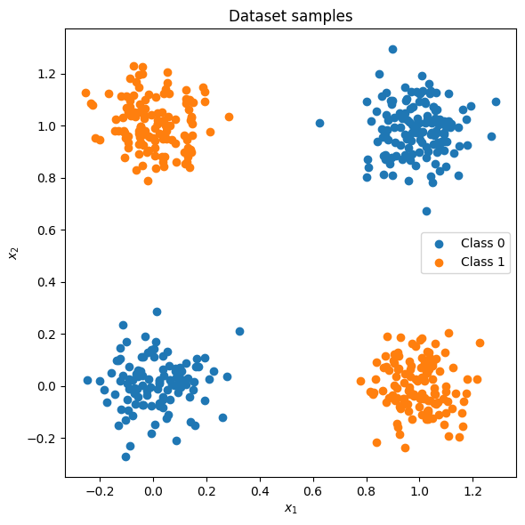

```python
print(train_dataset.data.shape)
#print(train_dataset.labels)

X = train_dataset.data
y = train_dataset.labels

def plot_dataset(X, y):
    plt.figure(figsize=(6, 6))
    plt.scatter(X[:, 0][y == 0], X[:, 1][y == 0], label="Class 0")
    plt.scatter(X[:, 0][y == 1], X[:, 1][y == 1], label="Class 1")
    plt.title("Dataset samples")
    plt.ylabel(r"$x_2$")
    plt.xlabel(r"$x_1$")
    plt.legend()
    plt.tight_layout()

plot_dataset(X, y)
```

Let us now use the dataloader to handle batches:

```python
print(train_dataset.data.shape)
dataloader = DataLoader(train_dataset, batch_size=4, shuffle=True)

# next(iter(...)) catches the first batch of the data loader
# If shuffle is True, it will randomly sample data from the dataset.
# For iterating over the whole dataset, we can simple use "for (x, d) in data_loader: ..."
x_batch, d_batch = next(iter(dataloader))

# The shape of the outputs are [batch_size, d_1,...,d_N] where d_1,...,d_N are the
# dimensions of the data point returned from the dataset class
print("Data inputs:", x_batch.shape)
print("Data labels:", d_batch.shape)
```

```
torch.Size([500, 2])
Data inputs: torch.Size([4, 2])
Data labels: torch.Size([4])
```

### Neural network

The module `torch.nn` defines a series of useful classes like linear networks layers, activation functions, loss functions, etc.

```python
import torch.nn as nn
```

As before, we will build a 2-layers neural network with two neurons in the hidden layer. Each linear layer has a weight matrix of the shape `[output, input]`, and a bias of the shape `[output]`. The Sigmoid activation function does not have any parameters.

```python
class XORClassifier(nn.Module):

    def __init__(self, n_inputs, n_hidden, n_outputs):
        super().__init__()
        # Initialize the modules we need to build the network
        self.linear1 = nn.Linear(n_inputs, n_hidden)
        self.act_fn1 = nn.Sigmoid()
        self.linear2 = nn.Linear(n_hidden, n_outputs)
        self.act_fn2 = nn.Sigmoid()

    def forward(self, x):
        # Perform the calculation of the model to determine the prediction
        h1 = self.linear1(x)
        a1 = self.act_fn1(h1)
        h2 = self.linear2(a1)
        y = self.act_fn2(h2)
        return y

model = XORClassifier(n_inputs=2, n_hidden=2, n_outputs=1)
print(model)
```

```
XORClassifier(
  (linear1): Linear(in_features=2, out_features=2, bias=True)
  (act_fn1): Sigmoid()
  (linear2): Linear(in_features=2, out_features=1, bias=True)
  (act_fn2): Sigmoid()
)
```

Print the model parameters:

```python
for name, param in model.named_parameters():
    print("Parameter %s, shape %s" % (name, str(param.shape)))
```

```
Parameter linear1.weight, shape torch.Size([2, 2])
Parameter linear1.bias, shape torch.Size([2])
Parameter linear2.weight, shape torch.Size([1, 2])
Parameter linear2.bias, shape torch.Size([1])
```

### Loss and optimizer

As before, we use the binary cross-entropy loss. For updating the parameters, PyTorch provides the package `torch.optim` that has most popular optimizers implemented. Here, we use Stochastic Gradient Descent (SGD).

```python
loss_fun = nn.BCELoss()
optimizer = torch.optim.SGD(model.parameters(), lr=0.1) # input to the optimizer are the parameters of the model
```

### Training

Let us now implement the training loop that performs the forward pass, calculates the loss, and apply backpropagation to update the weights.

```python
def train_model(model, optimizer, dataloader, loss_fun, num_epochs=200):
    # Set model to train mode
    model.train()

    # Training loop
    for epoch in range(num_epochs):
        for (data_inputs, data_labels) in dataloader:

            ## Step 1: Run the model on the input data
            preds = model(data_inputs)
            preds = preds.squeeze(dim=1) # Output is [Batch size, 1], but we want [Batch size]

            ## Step 2: Calculate the loss
            loss = loss_fun(preds, data_labels.float())

            ## Step 3: Perform backpropagation
            # Before calculating the gradients, we need to ensure that they are all zero.
            # Otherwise, the gradients would be accumulating to the previous ones.
            optimizer.zero_grad()
            # Perform backpropagation
            loss.backward()

            ## Step 4: Update the parameters
            optimizer.step()
```

```python
train_model(model, optimizer, dataloader, loss_fun)
```

Show the learned parameters:

```python
state_dict = model.state_dict()
print(state_dict)
```

```
OrderedDict([('linear1.weight', tensor([[-7.0720,  7.2979],
        [-7.4468,  7.0563]])), ('linear1.bias', tensor([ 3.5504, -3.6545])), ('linear2.weight', tensor([[-12.0329,  12.6109]])), ('linear2.bias', tensor([5.6249]))])
```

### Testing

**(Question)** Apply the network on a test set and visualize the decision boundary.

```python
def accuracy_score(y_test,y_pred) :
    good = 0
    for i in range(len(y_test)):
        if y_test[i] == y_pred[i]:
            good += 1
    return good / len(y_test)


test_dataset = XOR_Dataset(n_samples=100)
X_test = train_dataset.data
y_test = train_dataset.labels

model.eval()
y_pred_test = model(X_test)

y_pred_test[y_pred_test>0.5] = 1
y_pred_test[y_pred_test<=0.5] = 0

print("testing set score : {:.2f}".format(accuracy_score(y_test,y_pred_test)))
```

```
testing set score : 1.00
```

[figure not shown]

```python
pad, num = 0.1, 100

x1_min, x1_max = X_test[:, 0].min()-pad, X_test[:, 0].max()+pad
x2_min, x2_max = X_test[:, 1].min()-pad, X_test[:, 1].max()+pad
xx1, xx2 = np.meshgrid(np.linspace(x1_min, x1_max, num=num),
                       np.linspace(x2_min, x2_max, num=num))
X_mesh = np.stack((xx1.reshape(-1), xx2.reshape(-1)), axis=1)

Z = xx1.reshape(-1) + xx2.reshape(-1)
Z = Z.reshape(xx1.shape)

plt.contourf(xx1, xx2, Z, levels=100, cmap='coolwarm')

plt.imshow(y_pred_test.detach().numpy(), extent=[0, 1, 0, 1], origin='lower', cmap='coolwarm')
plt.scatter(X_test[:, 0], X_test[:, 1], c=y_pred_test.detach().numpy(), cmap='coolwarm')
plt.xlabel('x1')
plt.ylabel('x2')
plt.title('Learned XOR function')
plt.colorbar()
plt.tight_layout()
```